# Modèle de prédiction des prix de l’immobilier à Paris

**Objectif du projet**

Etablir un modèle de prédiction des prix des biens immobiliers sur Paris. La variable que l’on souhaite prédire est donc “price” (Target)

Installation des bibliothèques

```r
install.packages('corrplot')
library(corrplot)
install.packages('tidyverse')
library(tidyverse)
install.packages('ggpubr')
library(ggpubr)
```

Lecture du dataset

```r
data <- read.csv('C:/Users/utilisateur/Google Drive/microsoft_ia/POC_R/projetnuit/data/ParisHousing.csv')
head(data)
```

|  | squareMeters | numberOfRooms | hasYard | hasPool | floors | cityCode | cityPartRange | numPrevOwners | made | isNewBuilt | hasStormProtector | basement | attic | garage | hasStorageRoom | hasGuestRoom | price |
| --- | --- | --- | --- | --- | --- | --- | --- | --- | --- | --- | --- | --- | --- | --- | --- | --- | --- |
| 1 | 75523 | 3 | 0 | 1 | 63 | 9373 | 3 | 8 | 2005 | 0 | 1 | 4313 | 9005 | 956 | 0 | 7 | 7559082 |
| 2 | 80771 | 39 | 1 | 1 | 98 | 39381 | 8 | 6 | 2015 | 1 | 0 | 3653 | 2436 | 128 | 1 | 2 | 8085990 |
| 3 | 55712 | 58 | 0 | 1 | 19 | 34457 | 6 | 8 | 2021 | 0 | 0 | 2937 | 8852 | 135 | 1 | 9 | 5574642 |
| 4 | 32316 | 47 | 0 | 0 | 6 | 27939 | 10 | 4 | 2012 | 0 | 1 | 659 | 7141 | 359 | 0 | 3 | 3232561 |
| 5 | 70429 | 19 | 1 | 1 | 90 | 38045 | 3 | 7 | 1990 | 1 | 0 | 8435 | 2429 | 292 | 1 | 4 | 7055052 |
| 6 | 39223 | 36 | 0 | 1 | 17 | 39489 | 8 | 6 | 2012 | 0 | 1 | 2009 | 4552 | 757 | 0 | 1 | 3926647 |

```r
NA
```

Affichons les premières statistiques de base

```r
#affichage des colonnes du dataset
colnames(data)
```

```
 [1] "squareMeters"      "numberOfRooms"     "hasYard"           "hasPool"           "floors"
 [6] "cityCode"          "cityPartRange"     "numPrevOwners"     "made"              "isNewBuilt"
[11] "hasStormProtector" "basement"          "attic"             "garage"            "hasStorageRoom"
[16] "hasGuestRoom"      "price"
```

```r
#affichage des types de variables
str(data)
```

```
'data.frame':   10000 obs. of  17 variables:
 $ squareMeters     : int  75523 80771 55712 32316 70429 39223 58682 86929 51522 39686 ...
 $ numberOfRooms    : int  3 39 58 47 19 36 10 100 3 42 ...
 $ hasYard          : int  0 1 0 0 1 0 1 1 0 0 ...
 $ hasPool          : int  1 1 1 0 1 1 1 0 0 0 ...
 $ floors           : int  63 98 19 6 90 17 99 11 61 15 ...
 $ cityCode         : int  9373 39381 34457 27939 38045 39489 6450 98155 9047 71019 ...
 $ cityPartRange    : int  3 8 6 10 3 8 10 3 8 5 ...
 $ numPrevOwners    : int  8 6 8 4 7 6 9 4 3 8 ...
 $ made             : int  2005 2015 2021 2012 1990 2012 1995 2003 2012 2021 ...
 $ isNewBuilt       : int  0 1 0 0 1 0 1 1 1 1 ...
 $ hasStormProtector: int  1 0 0 1 0 1 1 0 1 1 ...
 $ basement         : int  4313 3653 2937 659 8435 2009 5930 6326 632 5198 ...
 $ attic            : int  9005 2436 8852 7141 2429 4552 9453 4748 5792 5342 ...
 $ garage           : int  956 128 135 359 292 757 848 654 807 591 ...
 $ hasStorageRoom   : int  0 1 1 0 1 0 0 0 1 1 ...
 $ hasGuestRoom     : int  7 2 9 3 4 1 5 10 5 3 ...
 $ price            : num  7559082 8085990 5574642 3232561 7055052 ...
```

```r
# taille du csv
dim(data)

#afficher les six premières années
head(data$made)
```

[output not shown]

```r
#affichage des stats du dataset
summary(data)
```

```
  squareMeters   numberOfRooms       hasYard          hasPool           floors          cityCode
 Min.   :   89   Min.   :  1.00   Min.   :0.0000   Min.   :0.0000   Min.   :  1.00   Min.   :    3
 1st Qu.:25099   1st Qu.: 25.00   1st Qu.:0.0000   1st Qu.:0.0000   1st Qu.: 25.00   1st Qu.:24694
 Median :50106   Median : 50.00   Median :1.0000   Median :0.0000   Median : 50.00   Median :50693
 Mean   :49870   Mean   : 50.36   Mean   :0.5087   Mean   :0.4968   Mean   : 50.28   Mean   :50225
 3rd Qu.:74610   3rd Qu.: 75.00   3rd Qu.:1.0000   3rd Qu.:1.0000   3rd Qu.: 76.00   3rd Qu.:75683
 Max.   :99999   Max.   :100.00   Max.   :1.0000   Max.   :1.0000   Max.   :100.00   Max.   :99953
 cityPartRange   numPrevOwners         made        isNewBuilt     hasStormProtector    basement         attic
 Min.   : 1.00   Min.   : 1.000   Min.   :1990   Min.   :0.0000   Min.   :0.0000    Min.   :    0   Min.   :    1
 1st Qu.: 3.00   1st Qu.: 3.000   1st Qu.:1997   1st Qu.:0.0000   1st Qu.:0.0000    1st Qu.: 2560   1st Qu.: 2512
 Median : 5.00   Median : 5.000   Median :2006   Median :0.0000   Median :0.0000    Median : 5092   Median : 5045
 Mean   : 5.51   Mean   : 5.522   Mean   :2005   Mean   :0.4991   Mean   :0.4999    Mean   : 5033   Mean   : 5028
 3rd Qu.: 8.00   3rd Qu.: 8.000   3rd Qu.:2014   3rd Qu.:1.0000   3rd Qu.:1.0000    3rd Qu.: 7511   3rd Qu.: 7540
 Max.   :10.00   Max.   :10.000   Max.   :2021   Max.   :1.0000   Max.   :1.0000    Max.   :10000   Max.   :10000
     garage       hasStorageRoom   hasGuestRoom        price
 Min.   : 100.0   Min.   :0.000   Min.   : 0.000   Min.   :   10314
 1st Qu.: 327.8   1st Qu.:0.000   1st Qu.: 2.000   1st Qu.: 2516402
 Median : 554.0   Median :1.000   Median : 5.000   Median : 5016180
 Mean   : 553.1   Mean   :0.503   Mean   : 4.995   Mean   : 4993448
 3rd Qu.: 777.2   3rd Qu.:1.000   3rd Qu.: 8.000   3rd Qu.: 7469092
 Max.   :1000.0   Max.   :1.000   Max.   :10.000   Max.   :10006771
```

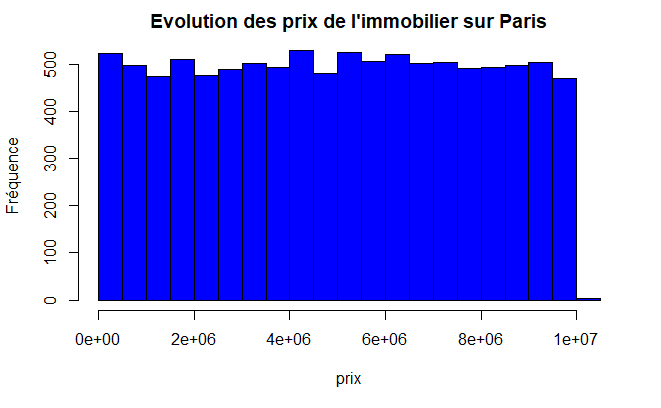

```r
hist(data$price, freq=TRUE, main="Evolution des prix de l'immobilier sur Paris", xlab="prix", ylab="Fréquence", col = "blue")
```

Le dataset comporte 17 variables numériques

**Corrélation des variables** Nous allons nous intéresser à la corrélation entre nos variables

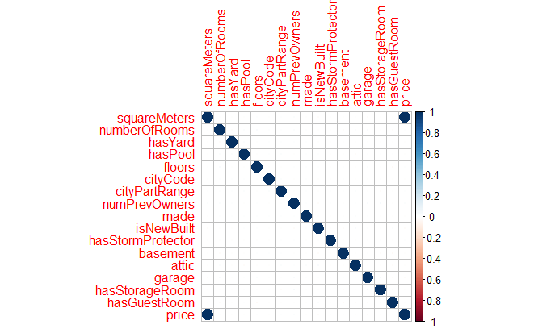

```r
#Matrice Corrélation
mcor <- cor(data)
corrplot(mcor, tl.col="red")
```

```r
cor(data$price, data$squareMeters, method = "pearson")
```

```
[1] 0.9999994
```

Nous constatons que seule la variable squareMeters est corrélée à 99% avec la variable price (TARGET)

Nous allons donc étudier la relation entre la target (price) et la variable explicative SquareMeters (surface).

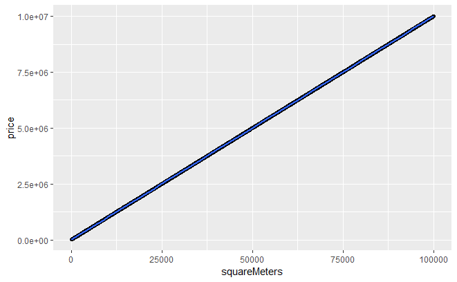

```r
#Visualisation du prix par rapport à la surface}
ggplot(data, aes(x = squareMeters, y = price)) +
  geom_point() +
  stat_smooth()
```

On observe une relation linéaire entre les variables “price” et “squareMeters”. L’équation de notre modèle est Y = aX + b + e.

Y (Target) est la variable “price” X est la variable explicative “squareMeters” e est le risque d’erreur de mon modèle.

Nous allons donc utiliser un modèle de régression linéaire simple pour effectuer nos prédictions de prix.

```r
#Modèle de régression linéaire simple
model <- lm(price ~ squareMeters, data=data)
model
```

```
Call:
lm(formula = price ~ squareMeters, data = data)

Coefficients:
 (Intercept)  squareMeters
        6461           100
```

L’équation de notre modèle de régression linéaire est donc:

price= 100*squareMeters + 6461 + E

```r
#Evaluation du modèle et affichage des coefficients du modèle
summary(model)
```

```
Call:
lm(formula = price ~ squareMeters, data = data)

Residuals:
    Min      1Q  Median      3Q     Max
-6155.9 -2406.8  -279.6  2158.0 12339.0

Coefficients:
              Estimate Std. Error  t value Pr(>|t|)
(Intercept)  6.461e+03  6.529e+01    98.95   <2e-16 ***
squareMeters 1.000e+02  1.134e-03 88177.45   <2e-16 ***
---
Signif. codes:  0 ‘***’ 0.001 ‘**’ 0.01 ‘*’ 0.05 ‘.’ 0.1 ‘ ’ 1

Residual standard error: 3263 on 9998 degrees of freedom
Multiple R-squared:      1, Adjusted R-squared:      1
F-statistic: 7.775e+09 on 1 and 9998 DF,  p-value: < 2.2e-16
```

```r
error <- sigma(model)*100/mean(data$price)
cat("Le pourcentage d'erreur du modèle est de",error,"%")
```

```
Le pourcentage d'erreur du modèle est de 0.06534673 %
```

```r
#Enregistrement du modèle qui sera utilisé pour les prédictions de prix
save(model, file="model.Rdata")
```

**visualisation et création d’un rapport: creer un rapport**

L’extension DataExplorer fournit des outils d’exploration graphique d’un fichier de données. En premier lieu, sa fonction create_report génère un rapport automatique à partir d’un tableau de données.

L’extension dataMaid propose une fonction makeCodebook permettant de générer une présentation de l’ensemble des variables d’un tableau de données, au format PDF, Word ou HTML.

```r
library(dataMaid)
makeCodebook(data)
```